# PA1_template

# What is mean total number of steps taken per day?

#### 1. Code for reading in the dataset and/or processing the data

```r
setwd("C:/tmp/")
data <- read.csv("./activity.csv")
str(data)
```

```
## 'data.frame':    17568 obs. of  3 variables:
##  $ steps   : int  NA NA NA NA NA NA NA NA NA NA ...
##  $ date    : Factor w/ 61 levels "10/1/2012","10/10/2012",..: 1 1 1 1 1 1 1 1 1 1 ...
##  $ interval: int  0 5 10 15 20 25 30 35 40 45 ...
```

#### 2. Histogram of the total number of steps taken each day

```r
library(dplyr)
data1 <- data %>% filter(!is.na(steps))  %>% group_by(date) %>%  summarize(steps_per_day = sum(steps, na.rm = TRUE))
```

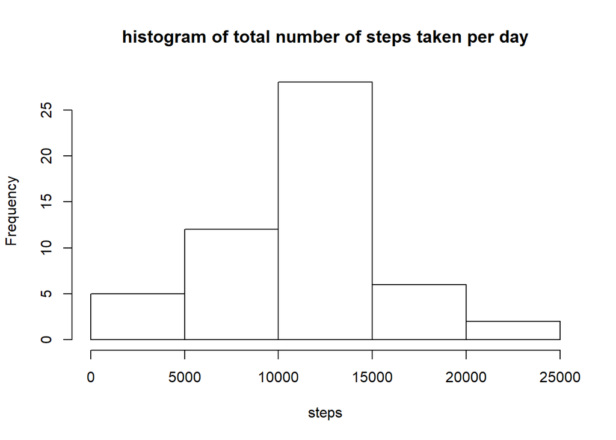

```r
hist(as.numeric(data1$steps_per_day), xlab = "steps", main = "histogram of total number of steps taken per day")
```

#### 3. Mean and median number of steps taken each day

```r
summary(data1$steps_per_day)
```

```
##    Min. 1st Qu.  Median    Mean 3rd Qu.    Max.
##      41    8841   10765   10766   13294   21194
```

# What is the average daily activity pattern?

#### 1.Time series plot of the 5-minute interval (x-axis) and the average number of steps taken, averaged across all days (y-axis)

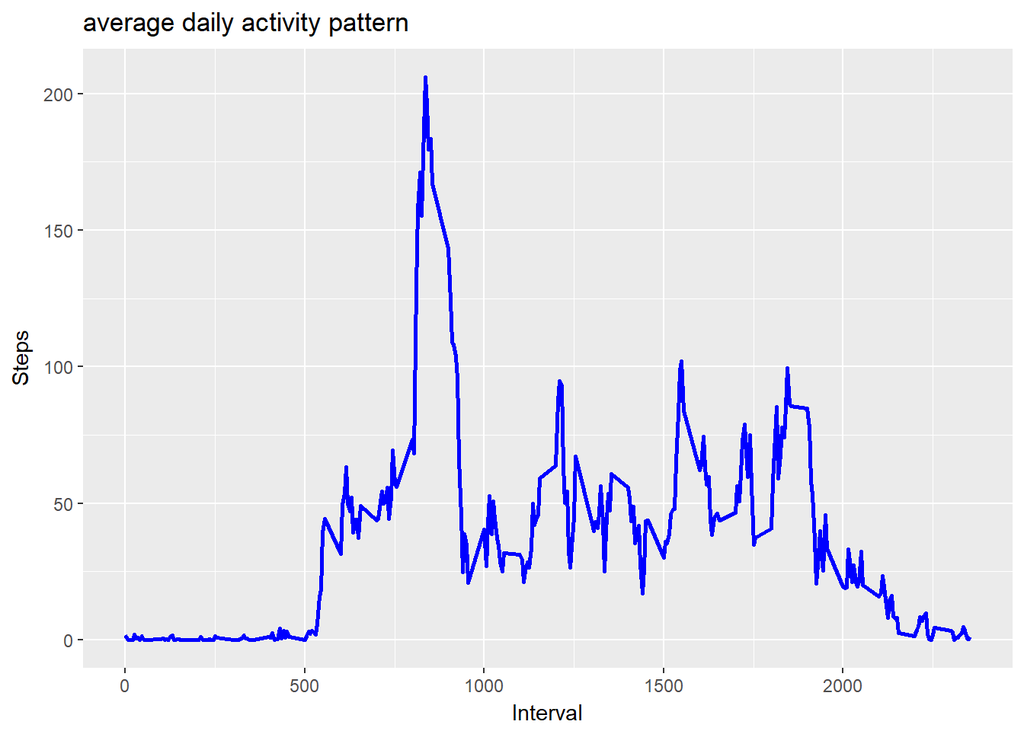

```r
library(ggplot2)
data2 <- data %>% filter(!is.na(steps)) %>% group_by(interval) %>%  summarize(average_steps_per_interval = mean(steps, na.rm = TRUE))
ggplot(data2, aes(interval, average_steps_per_interval)) +
           geom_line (na.rm=TRUE, color="blue", size=1) +
           ggtitle("average daily activity pattern") +
           xlab("Interval") + ylab("Steps")
```

#### 2. The 5-minute interval that, on average, contains the maximum number of steps

```r
max <- head(arrange(data2, desc(data2$average_steps_per_interval)),1)
```

The interval with maximum number of steps is 835.

# Imputing missing values

#### 1. The total number of missing values in the dataset

```r
m <- sum(is.na(data))
```

Total number of rows with NA is 2304.

#### 2. Create a new dataset that is equal to the original dataset but with the missing data filled in

##### The strategy for filling in all of the missing values in the dataset:

replace NA with the average number of steps taken per 5-minute interval

```r
data_impute <- mutate(left_join(data,data2, by = "interval"), steps_impute=  steps )
data_impute$steps_impute[which(is.na(data_impute$steps_impute))] <- data_impute$average_steps_per_interval
```

#### 3. Histogram of the total number of steps taken each day after imputing missing values

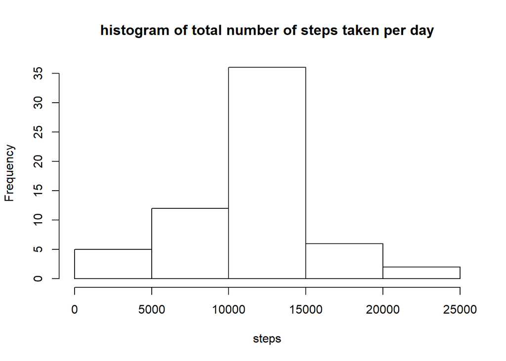

```r
data_impute1 <- data_impute %>% group_by(date) %>%  summarize(steps_per_day_impute = sum(steps_impute, na.rm = TRUE))
hist(as.numeric(data_impute1$steps_per_day_impute), xlab = "steps", main = "histogram of total number of steps taken per day")
```

#### 4. The mean and median of total number of steps taken per day after imputing missing values

```r
summary(data_impute1$steps_per_day_impute)
```

```
##    Min. 1st Qu.  Median    Mean 3rd Qu.    Max.
##      41    9819   10766   10766   12811   21194
```

Mean value after imputation stays the same but there is slight difference in median value.

# Are there differences in activity patterns between weekdays and weekends?

#### 1. Create a new factor variable in the dataset with two levels - “weekday” and “weekend”

```r
data_impute_factor <- mutate(data_impute, day=weekdays(as.Date(date)), factor = as.factor(ifelse(weekdays(as.Date(date)) %in% c('Saturday','Sunday'), c("weekend"), c("weekday"))))
head(data_impute_factor,3)
```

```
##   steps      date interval average_steps_per_interval steps_impute
## 1    NA 10/1/2012        0                  1.7169811    1.7169811
## 2    NA 10/1/2012        5                  0.3396226    0.3396226
## 3    NA 10/1/2012       10                  0.1320755    0.1320755
##         day  factor
## 1 Wednesday weekday
## 2 Wednesday weekday
## 3 Wednesday weekday
```

#### 2. The plot containing a time series plot of the 5-minute interval (x-axis) and the average number of steps taken, averaged across all weekday days or weekend days (y-axis)

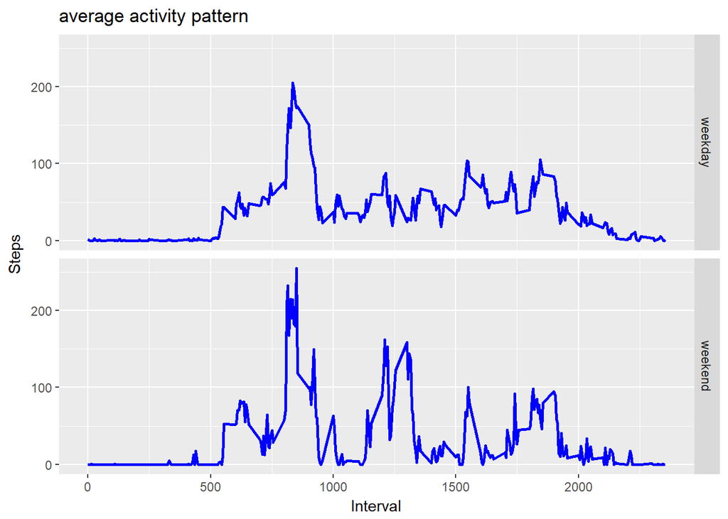

```r
data_final <- data_impute_factor %>% group_by(interval,factor) %>%  summarize(average_steps_per_interval_per_factor = mean(steps_impute))
ggplot(data_final, aes(interval, average_steps_per_interval_per_factor)) + facet_grid(factor ~ .) +
           geom_line (na.rm=TRUE, color="blue", size=1) +
           ggtitle("average activity pattern") +
           xlab("Interval") + ylab("Steps")
```